# Flight Delays: Patterns, Causes, and Avoidability

Fahtai Tanawongsuwan

2026-06-02

# Flight Delays Analysis Project

Author: Fahtai TANAWONGSUWAN (3036538194)

Modified from the author’s COMP2501 Intro to Data Science project - The University of Hong Kong

# Introduction

Flight delays are one of the most common frustrations in air travel. While many delays may appear random from a passenger’s perspective, large-scale flight data may reveal patterns behind them.

This project investigates whether flight delays are purely unlucky, or whether there are measurable factors that consistently correlate with delays.

The project focuses on three main questions:

1. Are there factors that consistently correlate with delays?
2. Can passengers choose flights strategically to reduce the probability of delays?
3. Was the author’s personal flight delay simply unlucky?

# Tools and Libraries

This project used R and R libraries including:

```r
library(dplyr)
library(ggplot2)
library(tidyverse)
library(readr)
library(lubridate)
library(ggrepel)
library(jsonlite)
```

# Data Sources

## United States Flight Data from 2024-2025

The primary dataset used in this project comes from the US Bureau of Transportation Statistics.

Data source: https://www.transtats.bts.gov/

The dataset contains information about individual flights, including:

- Origin and destination airports
- Airline carrier
- Scheduled departure and arrival times
- Actual departure and arrival times
- Delay information
- Flight distance

Dataset Advantages:

- Large number of observations
- Data is mostly clean, tidy and complete
- Data includes many features

## Hong Kong Flight Data

Additional flight data for Hong Kong International Airport (HKG) was collected from the Hong Kong Government open data API for flights departing HKG during March and April 2026.

Data source: https://data.gov.hk/en/

The HKG dataset was limited by limited data features and more importantly, limited historical data, with the API only able to access data from the 90 previous days. So it was used for a smaller and more specific case study investigating a personally experienced delayed flight.

# Loading the US Dataset

```r
years <- c("24","25")
months <- c("01","02","03","04","05","06","07","08","09","10","11","12")
dot_csv <- ".csv"

month_year <- expand.grid(m=months,y=years)
file_names <- paste0(month_year$y,month_year$m,dot_csv)

df <- data.frame()
for(i in file_names) {
  df <- bind_rows(df,read_csv(i, show_col_types = FALSE))
}

new_colnames <- c("year","month","date","day_of_week","carrier","uniq_carrier","flight_number","orig","orig_state","dest","dest_state","sch_dept","real_dept","sch_arrv","real_arrv","cancelled","cancel_code","sch_flight_time","real_flight_time","flight_distance","delay_carrier","delay_weather","delay_nas","delay_security","delay_late_aircraft")
colnames(df) <- new_colnames
flights <- df

print("Dataset size and head")
```

```
## [1] "Dataset size and head"
```

```r
dim(flights)
```

```
## [1] 14080700       25
```

```r
head(flights,6)
```

```
##   year month date day_of_week carrier uniq_carrier flight_number orig
## 1 2024     1    1           1      9E           9E          4814  JFK
## 2 2024     1    1           1      9E           9E          4815  MSP
## 3 2024     1    1           1      9E           9E          4817  JFK
## 4 2024     1    1           1      9E           9E          4817  RIC
## 5 2024     1    1           1      9E           9E          4818  DTW
## 6 2024     1    1           1      9E           9E          4822  JAX
##   orig_state dest dest_state sch_dept real_dept sch_arrv real_arrv cancelled
## 1         NY  DTW         MI     1252      1247     1508      1449         0
## 2         MN  CLE         OH     1015      1001     1325      1255         0
## 3         NY  RIC         VA     1415      1411     1601      1541         0
## 4         VA  JFK         NY     1650      1643     1841      1759         0
## 5         MI  MKE         WI     1015      1010     1034      1020         0
## 6         FL  LGA         NY     1410      1403     1627      1603         0
##   cancel_code sch_flight_time real_flight_time flight_distance delay_carrier
## 1        <NA>             136              122             509            NA
## 2        <NA>             130              114             622            NA
## 3        <NA>             106               90             288            NA
## 4        <NA>             111               76             288            NA
## 5        <NA>              79               70             237            NA
## 6        <NA>             137              120             833            NA
##   delay_weather delay_nas delay_security delay_late_aircraft
## 1            NA        NA             NA                  NA
## 2            NA        NA             NA                  NA
## 3            NA        NA             NA                  NA
## 4            NA        NA             NA                  NA
## 5            NA        NA             NA                  NA
## 6            NA        NA             NA                  NA
```

# Data Cleaning and Feature Engineering

The raw dataset obtained from the BTS query system was already relatively clean. However, several preprocessing steps were still required before analysis.

The following cleaning procedures were performed:

1. Remove cancelled flights
2. Replace missing values with 0
3. Convert time columns into proper time format
4. Create new variables for delays

In this project, a flight is defined as **delayed** if it **departs more than 30 minutes behind** schedule.

```r
# Remove cancelled flights
flights <- flights |>
  filter(cancelled == 0) |>
  select(-cancelled,-cancel_code,-uniq_carrier)

# Replace missing values
flights[is.na(flights)] <- 0

# Convert HHMM values into time format
hhmm_to_time <- function(x) {
  paste0(substr(x,1,2)," ",substr(x,3,4)) |> hm()
}
for(i in 11:14) {
  flights[[i]] <- hhmm_to_time(flights[[i]])
}

# Create delay variables
flights <- flights |>
  mutate(
    dept_delay_min = as.numeric(real_dept - sch_dept, units="mins"),
    arrv_delay_min = as.numeric(real_arrv - sch_arrv, units="mins"),
    dept_delay_min = ifelse(dept_delay_min < -720,
                            dept_delay_min + 1440,
                            dept_delay_min),
    arrv_delay_min = ifelse(arrv_delay_min < -720,
                            arrv_delay_min + 1440,
                            arrv_delay_min),
    dept_delay = ifelse(dept_delay_min > 30, TRUE, FALSE),
    delay_on_air = real_flight_time - sch_flight_time
  )

head(flights,10)
```

```
##    year month date day_of_week carrier flight_number orig orig_state dest
## 1  2024     1    1           1      9E          4814  JFK         NY  DTW
## 2  2024     1    1           1      9E          4815  MSP         MN  CLE
## 3  2024     1    1           1      9E          4817  JFK         NY  RIC
## 4  2024     1    1           1      9E          4817  RIC         VA  JFK
## 5  2024     1    1           1      9E          4818  DTW         MI  MKE
## 6  2024     1    1           1      9E          4822  JAX         FL  LGA
## 7  2024     1    1           1      9E          4822  LGA         NY  JAX
## 8  2024     1    1           1      9E          4823  CHS         SC  LGA
## 9  2024     1    1           1      9E          4823  LGA         NY  CHS
## 10 2024     1    1           1      9E          4828  ITH         NY  JFK
##    dest_state   sch_dept  real_dept   sch_arrv  real_arrv sch_flight_time
## 1          MI 12H 52M 0S 12H 47M 0S  15H 8M 0S 14H 49M 0S             136
## 2          OH 10H 15M 0S  10H 1M 0S 13H 25M 0S 12H 55M 0S             130
## 3          VA 14H 15M 0S 14H 11M 0S  16H 1M 0S 15H 41M 0S             106
```

[output cut: 40 more lines]

# Exploratory Data Analysis

The exploratory analysis focuses on identifying whether certain variables are associated with flight delays.

The variables were grouped into three categories:

| Category | Variables |
| --- | --- |
| Uncontrollable | Airport, Flight Distance |
| Semi-uncontrollable | Date |
| Mostly Controllable | Airline/Carrier |

## Airport Analysis

### Do Some Airports Experience More Delays?

One possible explanation for delays is airport congestion. Large airports process substantially more traffic, which may increase the likelihood of delays.

To investigate this, flights were grouped by origin airport.

```r
total_flights = summarize(flights,n()) %>% .[1,1]

flights_by_origin <- flights |>
                      group_by(orig) |>
                     summarize(delay_chance = round(mean(dept_delay)*100,digits=3),
                      proportion = n()/total_flights*100)
flights_by_origin <- left_join(flights_by_origin,
                               flights |> filter(dept_delay==TRUE) |>
                              group_by(orig) |>
                              summarize(average_delay=round(mean(dept_delay_min))),
                              join_by(orig))
flights_by_origin[is.na(flights_by_origin)] <- 0
```

### Delay Chance by Airport

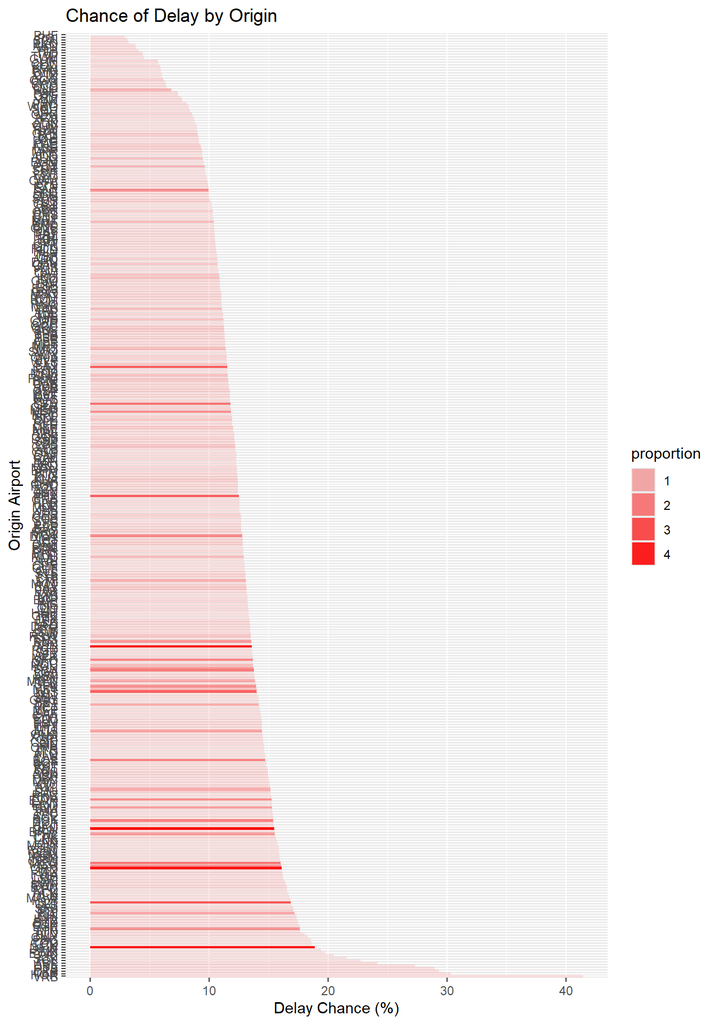

```r
plot_chance_by_origin <- ggplot(flights_by_origin,aes(x=reorder(orig,-delay_chance),y=delay_chance,alpha=proportion)) +
  geom_col(fill="red") + coord_flip() +
  ggtitle("Chance of Delay by Origin") + xlab("Origin Airport") + ylab("Delay Chance (%)")
plot_chance_by_origin
```

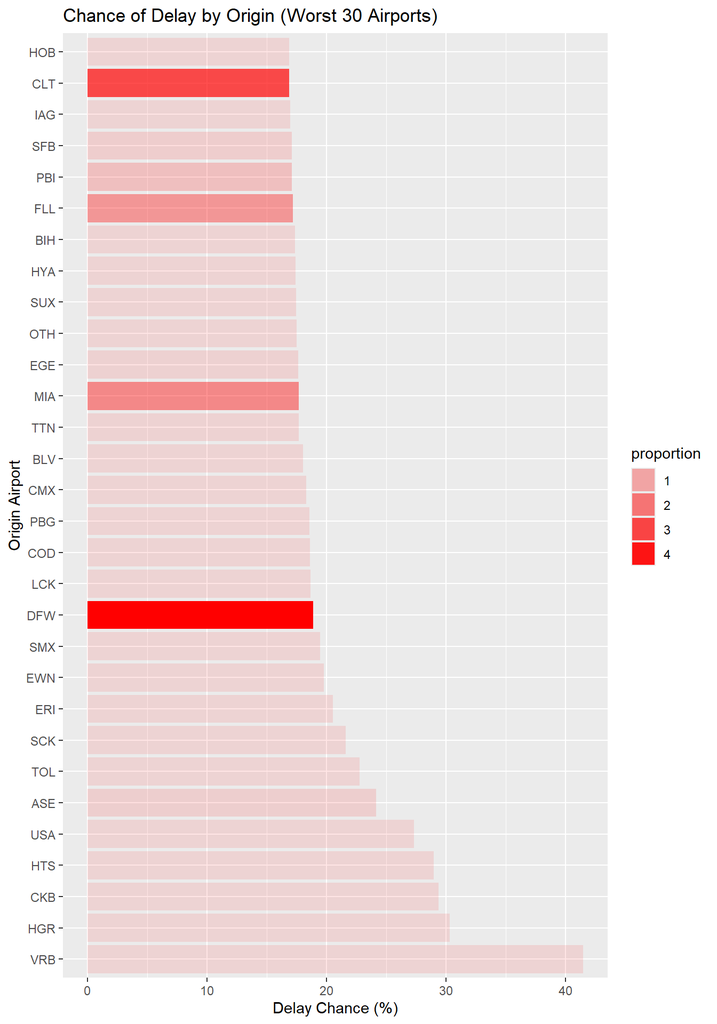

```r
plot_chance_by_origin_top <- ggplot(flights_by_origin |> arrange(desc(delay_chance)) |> head(30),aes(x=reorder(orig,-delay_chance),y=delay_chance,alpha=proportion)) +
  geom_col(fill="red") + coord_flip() +
  ggtitle("Chance of Delay by Origin (Worst 30 Airports)") + xlab("Origin Airport") + ylab("Delay Chance (%)")
plot_chance_by_origin_top
```

The analysis shows that some airports consistently experience relatively higher delay rates than others.

This suggests that airport choice may influence the probability of delays.

### Airport Size vs Delay Rate

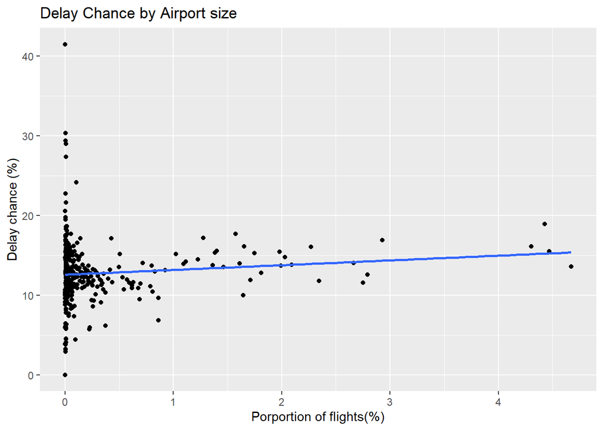

```r
plot_chance_vs_proportion <- flights_by_origin |>
  ggplot(aes(y=delay_chance,x=proportion)) + geom_point() + geom_smooth(method="lm",se=FALSE) + ggtitle("Delay Chance by Airport size") +
  xlab("Porportion of flights(%)") + ylab("Delay chance (%)")
plot_chance_vs_proportion
```

```r
cor(flights_by_origin$proportion,flights_by_origin$delay_chance)
```

```
## [1] 0.1004945
```

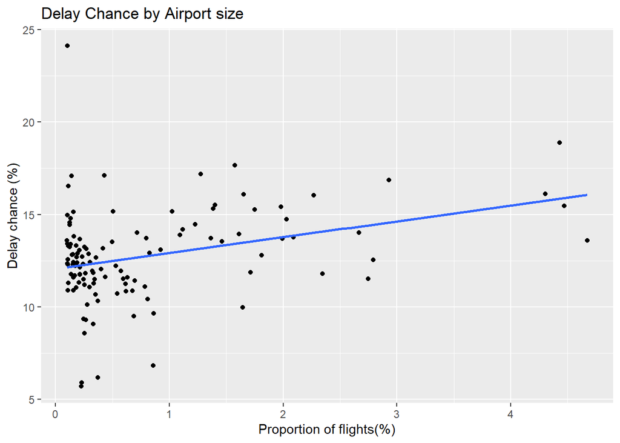

```r
plot_chance_vs_proportion_zoom <- flights_by_origin |> filter(proportion>0.1) |>
  ggplot(aes(y=delay_chance,x=proportion)) + geom_point() + geom_smooth(method="lm",se=FALSE) + ggtitle("Delay Chance by Airport size") +
  xlab("Proportion of flights(%)") + ylab("Delay chance (%)")
plot_chance_vs_proportion_zoom
```

```r
flights_by_origin_zoom <- flights_by_origin |> filter(proportion>0.1)
cor(flights_by_origin_zoom$proportion,flights_by_origin_zoom$delay_chance)
```

```
## [1] 0.3316031
```

The relationship between airport size and delay probability is positive but relatively weak.

- Using all airports, the correlation is weak.
- Among sufficiently large airports, the relationship remains weak-to-moderate.

## Flight Distance Analysis

### Do Longer Flights Experience More Delays?

A common assumption is that longer flights may experience greater delays.

```r
flights_by_distance <- flights |>
  mutate(distance_group = cut(flight_distance, breaks=20)) |>
  group_by(distance_group) |>
  summarize(
    delay_chance = mean(dept_delay)*100,
    avg_delay = mean(dept_delay_min)
  )

head(flights_by_distance)
```

```
## # A tibble: 6 × 3
##   distance_group      delay_chance avg_delay
##   <fct>                      <dbl>     <dbl>
## 1 (5.92,265]                  12.6      10.3
## 2 (265,519]                   13.1      10.6
## 3 (519,774]                   14.0      11.9
## 4 (774,1.03e+03]              14.5      12.8
## 5 (1.03e+03,1.28e+03]         14.9      13.2
## 6 (1.28e+03,1.54e+03]         13.8      12.3
```

The analysis found little evidence that longer flights are substantially more likely to be delayed.

Flight distance appears to have minimal impact on delay probability. Long-distance flights may experience slightly longer delays on average, but the difference is negligible.

## Seasonal and Date Analysis

### Do Holidays and Peak Seasons Increase Delays?

One possible factor affecting flight delays is travel demand. During holidays and peak travel seasons, airports and airlines must handle substantially larger passenger volumes, which may increase congestion throughout the aviation network.

To investigate this relationship, flights were grouped by calendar date and two metrics were calculated:

- **Delay chance**: the proportion of flights departing more than 30 minutes late.
- **Average delay duration**: the mean departure delay in minutes.

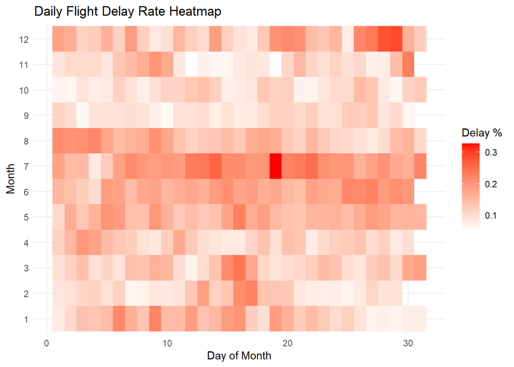

```r
flights_by_date <- flights |> group_by(month,date) |> summarize(delay_chance = mean(dept_delay), delay_duration = mean(dept_delay_min), .groups = "drop")

plot_chance_by_date <- ggplot(flights_by_date, aes(x = date, y = factor(month), fill = delay_chance)) +
  geom_tile() +
  scale_fill_gradient(low = "white", high = "red") +
  labs(
    title = "Daily Flight Delay Rate Heatmap",
    x = "Day of Month",
    y = "Month",
    fill = "Delay %"
  ) + theme_minimal()
plot_chance_by_date
```

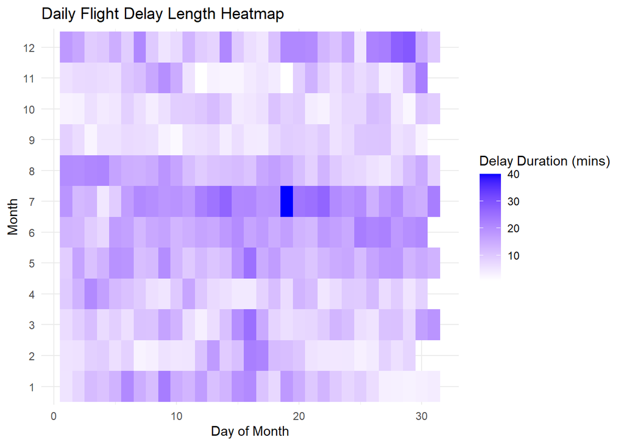

```r
plot_duration_by_date <- ggplot(flights_by_date, aes(x = date, y = factor(month), fill = delay_duration)) +
  geom_tile() +
  scale_fill_gradient(low = "white", high = "blue") +
  labs(
    title = "Daily Flight Delay Length Heatmap",
    x = "Day of Month",
    y = "Month",
    fill = "Delay Duration (mins)"
  ) + theme_minimal()
plot_duration_by_date
```

The heatmaps reveal several periods where delays become more frequent. Some of these periods align closely with major US travel seasons and holidays, suggesting that increased passenger demand may contribute to flight disruptions.

Notable periods include:

- **Late December** - Christmas and year-end holiday season
- **Late November** - Thanksgiving travel period
- **Mid-March** - spring travel season, around school holidays
- **Early August** - near the end of the summer vacation season

### Outliers: External Events

While many delay patterns appear seasonal, several periods do not perfectly align on the heatmaps. Unlike holiday periods, these spikes are concentrated on individual days and are likely caused by specific one-time disruptions rather than increased travel demand or a regular occurence.

Several notable examples were identified:

- **9 January 2024** – a major winter storm affected large portions of the United States, disrupting airport operations and causing widespread delays.
- **19 July 2024** – the global CrowdStrike outage disrupted airline and airport computer systems, resulting in significant operational delays across multiple carriers. This resulted in an outlier point with the most significant delay rates and times in the heatmap.
- **5 August 2025** – Hurricane Debby impacted the southeastern United States, producing severe disruptions to flight schedules.

After identifying and accounting for extreme outlier dates caused by one-off external disruption, a clearer seasonal pattern emerges. The remaining high-delay regions on the heatmaps are concentrated around major travel periods, including Thanksgiving, the Christmas and New Year holiday season, spring travel periods, and the end of summer vacation. While it does not establish a causal relationship, the consistent appearance of these periods suggests that increased travel demand during peak seasons is associated with an elevated flight delay.

## Airline Analysis

### Do Some Airlines Delay More Than Others?

One variable that passengers can choose in air travel is the airline or carrier, so we want to investigate if different airlines have different patterns and if delays can become a factor when booking an airline. First, we group the data by airline and plot airline size and delay rate.

```r
flights_by_airline <- flights |> group_by(carrier) |>
  summarize(delay_chance = round( mean(dept_delay)*100, digits=3),
            proportion = round(n()/total_flights*100, digits=2))

flights_by_airline <- left_join(flights_by_airline,
          flights |> filter(dept_delay==TRUE) |>
            select(carrier,dept_delay_min,delay_carrier,delay_late_aircraft) |>
            group_by(carrier) |>
            summarize(
              average_delay = mean(dept_delay_min),
              delay_carrier = mean(delay_carrier),
              delay_late_aircraft = mean(delay_late_aircraft)
            ), by = "carrier")

flights_by_airline |> arrange(desc(delay_chance)) |> head(10)
```

```
## # A tibble: 10 × 6
##    carrier delay_chance proportion average_delay delay_carrier
##    <chr>          <dbl>      <dbl>         <dbl>         <dbl>
##  1 F9              19.2       2.87          99.7          25.2
##  2 B6              17.8       3.34          97.4          30.7
##  3 AA              17.3      13.9          102.           32.4
##  4 OH              16.2       3.33         106.           30.9
##  5 NK              15.8       3.23          93.3          23.7
##  6 G4              14.7       1.77          98.0          28.5
##  7 WN              13.5      20.1           76.9          19.6
##  8 UA              12.8      11.1           99.8          26.6
##  9 OO              12.6      11.3          105.           48.9
## 10 MQ              11.8       4.1           87.8          20.4
## # ℹ 1 more variable: delay_late_aircraft <dbl>
```

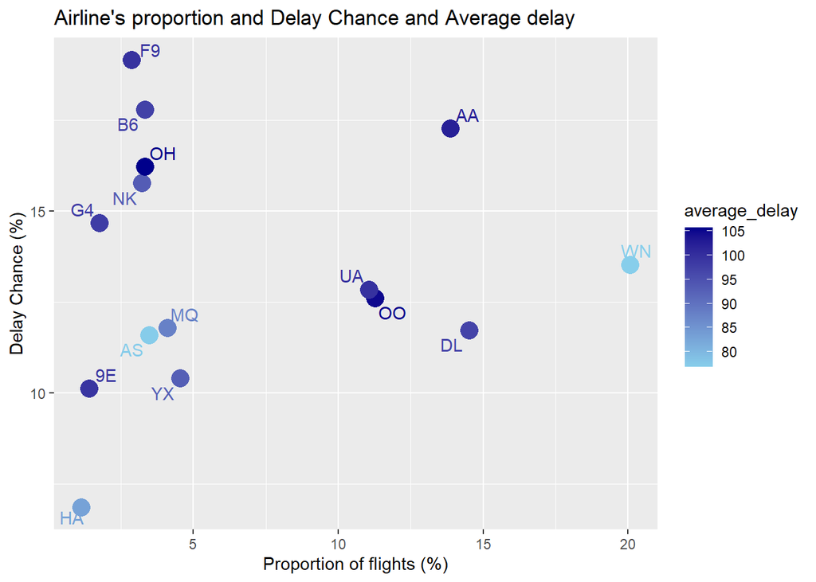

```r
plot_chance_by_airline <- flights_by_airline |> ggplot(aes(x=proportion,y=delay_chance, col=average_delay,label=carrier)) +
  geom_point(size=5) +
  scale_color_gradient(low = "skyblue", high = "blue4",) +
  geom_text_repel() +
  ggtitle("Airline's proportion and Delay Chance and Average delay") +
  xlab("Proportion of flights (%)") + ylab("Delay Chance (%)")
plot_chance_by_airline
```

The analysis found that some airlines delay more frequently and longer than others, but there is no correlation between airline size, measured by the proportion of flights operated by that airline, and delay rate or length. Therefore, choosing a popular or big airline does not automatically it is better or worse in terms of delays, but we have to look at the specific airline statistics.

Worst performing airlines include:

- (F9) Frontier Airlines - 19.15% delayed; 99.69 minutes on average
- (B6) JetBlue - 17.78% delayed; 97.44 minutes on average
- (AA) American Airlines - 17.26%; 102.25 minutes on average

The best performing airline by a margin was (HA) Hawaiian Air 6.86% delayed; 83.13 minutes on average.

The observed differences suggest airline selection may affect delay probability.

# Can Passengers Reduce Delay Risk?

The historical data analysis suggests that passengers may be able to reduce delay probability by choosing:

- Less delay-prone airports
- Less congested travel dates
- Airlines with stronger delay performance
- Specific flights with historically lower delay rates (shown in later case study)

This suggests that historical flight statistics may help passengers make better travel decisions.

# Case Study: Personal flight delay (CX362, HKG)

## Motivation

The second part of the project investigates a personal delayed flight experience. A quick story, I thought about this project topic when I was sitting at Hong Kong International Airport on the evening of April 2, 2026 waiting for my CX362 flight, then a notification came that the flight has been delayed. So I wanted to use data science to not only investigate all flights, but also that specific flight and if it was avoidable.

The key question was:

> Was that delayed flight simply unlucky?

> Was it avoidable?

## Collecting Hong Kong Flight Data

Additional data from Hong Kong International Airport (HKG) was collected using the Hong Kong Government API. However, the data was limited because the API only provides 90 days of historical data and contains fewer variables than the US dataset.

Flight information for March and April 2026 (around the incident) was collected using API requests.

This is the original code to pull API

BUT API only available for 90 days after March 1, 2026

Alternative datasource below (exported original to CSV previously)

```r
# This code chunk does not work
# This is the original code to pull API
# BUT API only available for 90 days after March 1, 2026
# Alternative datasource below (exported original previously)


dates_MarApr2026 <- seq(
  from = as.Date("2026-03-01"),
  to = as.Date("2026-04-30"),
  by = "day"
)

get_flights <- function(d){

  url <- paste0(
    "https://www.hongkongairport.com/flightinfo-rest/rest/flights/past?date=",
    d,
    "&lang=en&cargo=false&arrival=false"
  )

  tryCatch(
    raw <- fromJSON(url)$list[[1]] |> as_tibble(),
    error = function(e) NULL
  )

  raw <- raw |> select(time,flight,status,destination) |>
      filter(status!="Cancelled") |>
      unnest(destination) |>
      mutate(sch_dept = hm(time),
            real_dept = hm(substr(status,5,9)),
            delay_min = as.numeric(real_dept - sch_dept, unit="mins"),
            delay_min = ifelse(delay_min < -720, delay_min + 1440, delay_min),
            delayed = ifelse(delay_min>30,TRUE,FALSE),
            day = substr(d,9,10),
            month = substr(d,6,7),
            date = paste0(month,day))
  return(raw)
}

flights_hk <- map(dates_MarApr2026, get_flights)
flights_hk <- bind_rows(flights_hk)
flights_hk_unnested <- flights_hk |> unnest(flight)

head(flights_hk,10)
head(flights_hk_unnested,10)
```

```r
#Import data if API past 90 days
#PS Original CSV is lost, data only available from Mar3 - Apr30 (2 days missing)

flights_hk_unnested <- readRDS("flights_hk_unnested3.rds")
flights_hk <- readRDS("flights_hk3.rds")


head(flights_hk,10)
```

```
## # A tibble: 10 × 11
##    time  flight status    destination sch_dept real_dept delay_min delayed day
##    <chr> <list> <chr>     <chr>       <Period> <Period>      <dbl> <lgl>   <chr>
##  1 00:05 <df>   Dep 00:07 HND         5M 0S    7M 0S             2 FALSE   03
##  2 00:05 <df>   Dep 00:13 ICN         5M 0S    13M 0S            8 FALSE   03
##  3 00:25 <df>   Dep 00:46 CDG         25M 0S   46M 0S           21 FALSE   03
##  4 00:25 <df>   Dep 00:36 FRA         25M 0S   36M 0S           11 FALSE   03
##  5 00:30 <df>   Dep 00:44 MEL         30M 0S   44M 0S           14 FALSE   03
##  6 00:30 <df>   Dep 00:44 BRU         30M 0S   44M 0S           14 FALSE   03
##  7 00:30 <df>   Dep 00:33 JNB         30M 0S   33M 0S            3 FALSE   03
##  8 00:30 <df>   Dep 00:37 LAX         30M 0S   37M 0S            7 FALSE   03
##  9 00:40 <df>   Dep 00:36 ICN         40M 0S   36M 0S           -4 FALSE   03
## 10 00:40 <df>   Dep 00:53 MAD         40M 0S   53M 0S           13 FALSE   03
## # ℹ 2 more variables: month <chr>, date <chr>
```

```r
head(flights_hk_unnested,10)
```

```
## # A tibble: 10 × 12
##    time  no      airline status destination sch_dept real_dept delay_min delayed
##    <chr> <chr>   <chr>   <chr>  <chr>       <Period> <Period>      <dbl> <lgl>
##  1 00:05 NH 814  ANA     Dep 0… HND         5M 0S    7M 0S             2 FALSE
##  2 00:05 TW 644  TWB     Dep 0… ICN         5M 0S    13M 0S            8 FALSE
##  3 00:25 CX 261  CPA     Dep 0… CDG         25M 0S   46M 0S           21 FALSE
##  4 00:25 CX 289  CPA     Dep 0… FRA         25M 0S   36M 0S           11 FALSE
##  5 00:25 LH 7015 DLH     Dep 0… FRA         25M 0S   36M 0S           11 FALSE
##  6 00:30 CX 105  CPA     Dep 0… MEL         30M 0S   44M 0S           14 FALSE
##  7 00:30 AY 5095 FIN     Dep 0… MEL         30M 0S   44M 0S           14 FALSE
##  8 00:30 BA 4567 BAW     Dep 0… MEL         30M 0S   44M 0S           14 FALSE
##  9 00:30 OM 5605 MGL     Dep 0… MEL         30M 0S   44M 0S           14 FALSE
## 10 00:30 CX 291  CPA     Dep 0… BRU         30M 0S   44M 0S           14 FALSE
## # ℹ 3 more variables: day <chr>, month <chr>, date <chr>
```

## HKG Airport Performance

To evaluate HKG’s overall performance, we take HKG’s delay percentage and compare with the airports in the US dataset and the mean of the US dataset.

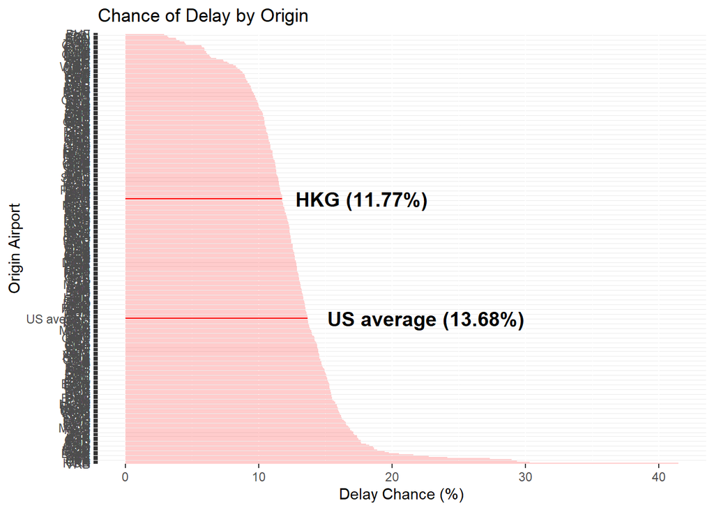

```r
hkg_delay_percentage <- count(flights_hk,delayed)[2,2] / count(flights_hk) *100
us_delay_percentage <- count(flights,dept_delay)[2,2] / count(flights) *100

hkg_df <- data.frame(orig="HKG", delay_chance=hkg_delay_percentage[1,1])
us_avg_df <- data.frame(orig="US average", delay_chance=us_delay_percentage[1,1])
flights_by_origin_andhk <- bind_rows(flights_by_origin,hkg_df)
flights_by_origin_andhk <- bind_rows(flights_by_origin_andhk,us_avg_df)

plot_chance_by_origin_HKG <- ggplot(
  flights_by_origin_andhk,
  aes(
    x = reorder(orig, -delay_chance),
    y = delay_chance,
    alpha = orig %in% c("HKG", "US average")
  )
) +
  geom_col(fill = "red") +
  coord_flip() +
  scale_alpha_manual(values = c("TRUE" = 1, "FALSE" = 0.2)) +
  ggtitle("Chance of Delay by Origin") +
  xlab("Origin Airport") +
  ylab("Delay Chance (%)") +
  geom_text(
    data = subset(flights_by_origin_andhk, orig %in% c("HKG", "US average") ),
    aes(label = paste0(orig, " (", round(delay_chance, 2), "%)")),
    hjust = -0.1,
    size = 5,
    fontface = "bold"
  ) +
  guides(alpha = "none")
plot_chance_by_origin_HKG
```

## Was the specific Flight Delay Unlucky?

So we take a look at flights statistics on that April 2, 2026, from that airline Cathay Pacific, and heading to the same destination PVG, and compare them to HKG’s average.

```r
#Delay Chance on that specific date (April 2,2026)
flights_hk |> filter(day=="02" & month=="04") |> summarize(Apr2_delay_chance=mean(delayed)) %>% pull()
```

```
## [1] 0.1698514
```

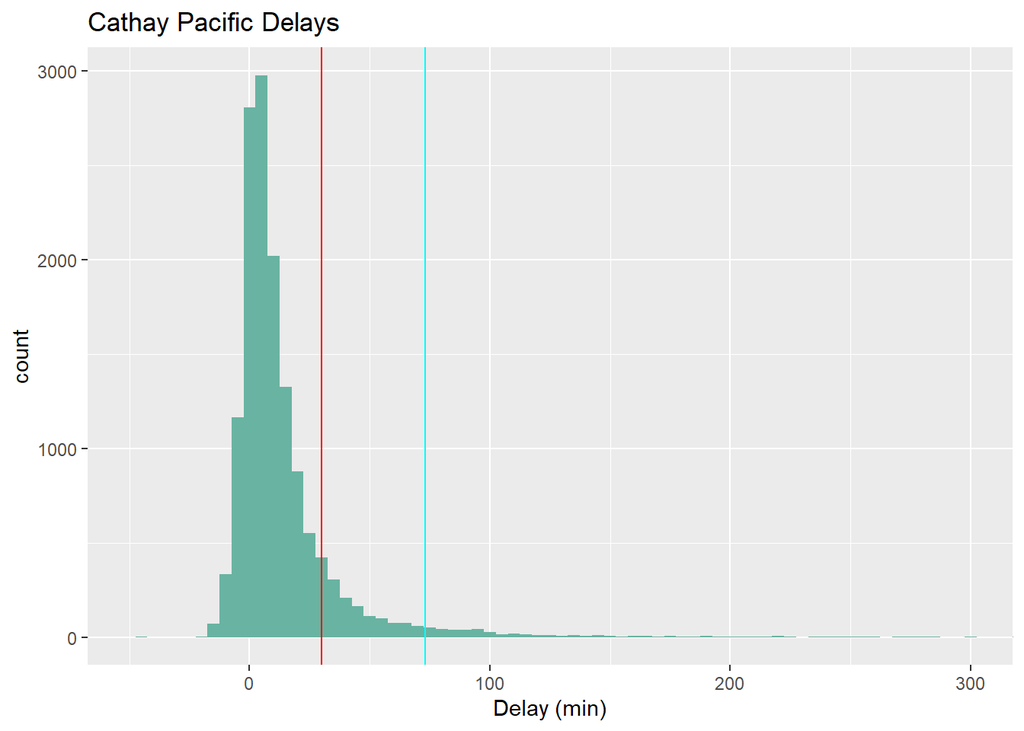

```r
#Delay Count of that specific airline (CPA Cathay Pacific)
Cathay <- flights_hk_unnested |> filter(airline=="CPA")
plot_Cathay <- Cathay |> ggplot(aes(delay_min)) +
  geom_histogram(binwidth = 5, fill="#69b3a2") +
  geom_vline(xintercept = 30,col="red") +
  geom_vline(xintercept = 73, col="cyan") +
  coord_cartesian(xlim = c(-50, 300)) +
  xlab("Delay (min)") + ylab("count") + ggtitle("Cathay Pacific Delays")
plot_Cathay
```

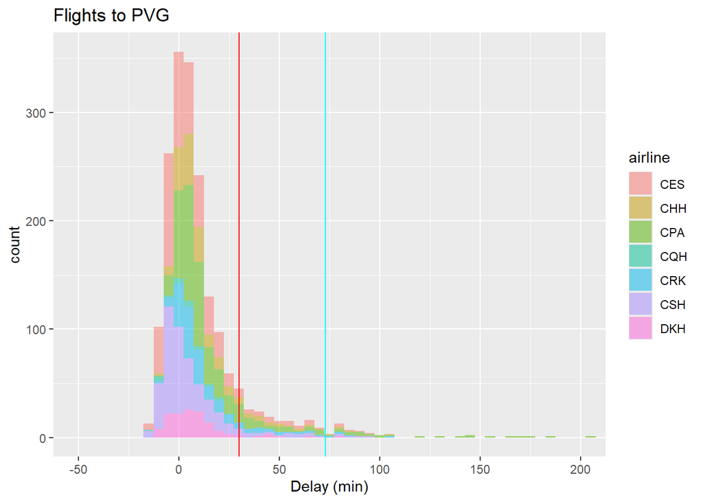

```r
#Delay Count of flights from HKG to PVG
PVG <- flights_hk_unnested |> filter(destination=="PVG")
plot_PVG <- PVG |> ggplot(aes(delay_min,fill=airline)) +
  geom_histogram(binwidth = 5,alpha=0.5) +
  geom_vline(xintercept = 30,col="red") +
  geom_vline(xintercept = 73, col="cyan") +
  coord_cartesian(xlim = c(-50, 200)) +
  xlab("Delay (min)") + ylab("count") + ggtitle("Flights to PVG")
plot_PVG
```

Also, to test that it was indeed unlucky, we find the p-value and assume the null hypothesis is

- Flights on April 2, 2026 delayed with same probability as HKG’s average (+6% was just unlucky)
- Flights by CPA delayed with same probability as HKG’s average (the airline is not the problem)

```r
#Calculate p-values to test if date and airlines are normal
HKG_delayed <- flights_hk |> group_by(delayed) |> count()

Apr2_delayed <- flights_hk_unnested |> filter(day=="02" & month=="04") |> group_by(delayed) |> count()
CPA_delayed <- flights_hk_unnested |> filter(airline=="CPA") |> group_by(delayed) |> count()

HKG_vs_Apr2 <- matrix(
  c(HKG_delayed[[2]][2], HKG_delayed[[2]][1],
    Apr2_delayed[[2]][2], Apr2_delayed[[2]][1]),
  nrow = 2,
  byrow = TRUE
)
HKG_vs_Apr2
```

```
##      [,1]  [,2]
## [1,] 3079 23083
## [2,]  175   826
```

```r
chisq.test(HKG_vs_Apr2)
```

```
##
##  Pearson's Chi-squared test with Yates' continuity correction
##
## data:  HKG_vs_Apr2
## X-squared = 29.309, df = 1, p-value = 6.172e-08
```

```r
HKG_vs_CPA <- matrix(
  c(HKG_delayed[[2]][2], HKG_delayed[[2]][1],
    CPA_delayed[[2]][2], CPA_delayed[[2]][1]),
  nrow = 2,
  byrow = TRUE
)
HKG_vs_CPA
```

```
##      [,1]  [,2]
## [1,] 3079 23083
## [2,] 1712 12399
```

```r
chisq.test(HKG_vs_CPA)
```

```
##
##  Pearson's Chi-squared test with Yates' continuity correction
##
## data:  HKG_vs_CPA
## X-squared = 1.1206, df = 1, p-value = 0.2898
```

From the p-values we conclude that:

1. The April 2, 2026 hypothesis has a very low p-value, indicating the null-hypothesis is false, so flights on that specific date has a higher chance of delaying than average. Also, April 2, 2026 is the evening before a five day holiday in Hong Kong (Qingming festival and Easter break), thus a peak travel season, which follows our previous conclusion that peak travel seasons correlate with more delays. So it was not unlucky, rather it is expected because of the flight date.
2. Cathay Pacific has a 0.28 p-value, which indicates that it is statistically insignificant. Therefore this particular CPA flight was probably unlucky, not the airline being worse performing.

## Was that particular delay avoidable?

Previously, factors that passengers can choose are airlines and specific flights, so we take a look at both.

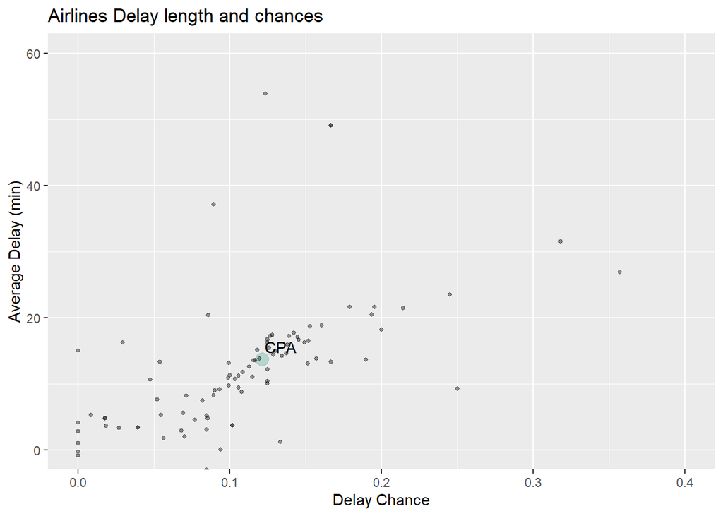

```r
plot_HKG_by_airline <- flights_hk_unnested |>
  group_by(airline) |>
  summarize(delay_min=mean(delay_min),delay_chance=mean(delayed)) |>
  ggplot(aes(x=delay_chance,y=delay_min)) +
  geom_point(aes(color = airline == "CPA",size = airline == "CPA"),alpha=0.4) +
  geom_text_repel(data =\(x) subset(x, airline == "CPA"),aes(label = airline)) +
  scale_color_manual(values = c("TRUE" = "#69b3a2", "FALSE" = "black")) +
  coord_cartesian(xlim = c(0, 0.4), ylim = c(0, 60)) +
  labs(x="Delay Chance",y="Average Delay (min)") +
  scale_size_manual(values = c("TRUE" = 4, "FALSE" = 1)) +
  guides(color = "none",size="none",color="none") +
  ggtitle("Airlines Delay length and chances")
plot_HKG_by_airline
```

From the plot of all airlines’ delay chance and delay length, we can see that there are airlines that are statically better that Cathay Pacific in terms of delay. So the delay can be slightly avoidable if I choose another better performing airline.

However, if we take a look at CX362 in particular:

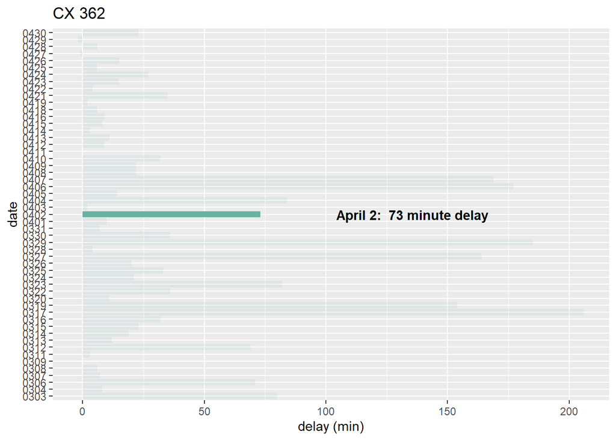

```r
CX362 <- flights_hk_unnested |> filter(no=="CX 362")
plot_CX362 <- CX362 |> ggplot(aes(x=reorder(date, as.numeric(date)),y=delay_min, alpha = ifelse(date=="0402",1,0.9))) +
  geom_col(fill="#69b3a2") + ggtitle("CX 362") + coord_flip() +
  xlab("date") + ylab("delay (min)") +
  geom_text(
    data = subset(CX362, date == "0402"),
    aes(label = paste("April 2: ",delay_min,"minute delay")),
    hjust = -0.5,
    fontface = "bold"
  ) +
  guides(alpha="none",size="none",color="none")
plot_CX362
```

We see that CX362 on April 2, 2026 was not nearly the worst performer, and there are significantly more delays than the normal 12% for CPA, so the problem might be that particular flight.

To confirm, we find the p-value with the null hypothesis being that CX362 has a same delay chance as HKG’s average.

```r
CX362_delayed <- flights_hk_unnested |> filter(no=="CX 362") |> group_by(delayed) |> count()
HKG_vs_CX362 <- matrix(
  c(HKG_delayed[[2]][2], HKG_delayed[[2]][1],
    CX362_delayed[[2]][2], CX362_delayed[[2]][1]),
  nrow = 2,
  byrow = TRUE
)

HKG_vs_CX362
```

```
##      [,1]  [,2]
## [1,] 3079 23083
## [2,]   18    35
```

```r
chisq.test(HKG_vs_CX362)
```

```
##
##  Pearson's Chi-squared test with Yates' continuity correction
##
## data:  HKG_vs_CX362
## X-squared = 22.921, df = 1, p-value = 1.688e-06
```

From the extremely small p-value, we conclude that the delay rate of CX362 differs significantly from the overall HKG average. So a part of the problem is from flight CX362’s external factors, and the delay was more avoidable if I had chosen another flight!

# Key Takeaways

The project produced several major findings:

1. Some airports consistently experience more delays than others.
2. Peak travel seasons tend to increase delay probability.
3. Airlines differ noticeably in delay frequency and severity.
4. Flight distance has relatively little effect on delay probability.
5. Choosing flights from historical data can partially help passengers reduce delay risk.

Overall, flight delays are not purely random. While luck still plays a role, historical patterns reveal meaningful trends that may help explain, predict and avoid delays.

# Limitations

Several limitations should be acknowledged:

- Weather data was not directly integrated into the analysis.
- The Hong Kong dataset was relatively small.
- Delay causes may overlap across operational categories.
- Correlation does not imply causation.

Future work could incorporate:

- Machine learning prediction models
- Weather APIs
- Time-of-day analysis
- Route network analysis
- Real-time delay prediction

# Conclusion

This project explored whether flight delays are random or whether identifiable patterns exist.

Using large-scale flight datasets from the United States, the analysis found that airports, airlines, seasonal demand, and major incidents all correlate with delays.

Although passengers cannot fully eliminate delay risk, historical flight data can improve understanding of when and where delays are more likely to occur, as shown from the Hong Kong flight data.

# References

## Data Sources

- Hong Kong Government Open Data API https://data.gov.hk/en/
- US Bureau of Transportation Statistics https://www.bts.gov/